# ЕГЭ 2018 Вариант 17 EGE 2018 Variant 17

### Задание 7 / Task 7

На рисунке изображены график функции y=f′(x) - производной функции f(x), и восемь точек на оси абсцисс:

The figure shows the graph of the function y′=f(x) - the derivative of the function f(x), and eight points on the abscissa:

$x_1,x_2,x_3,x_4,x_5,x_6,x_7,x_8$.

Сколько из этих точек принадлежат промежуткам убывания функции f(x)?

How many of these points belong to the decreasing intervals of the function f(x)?

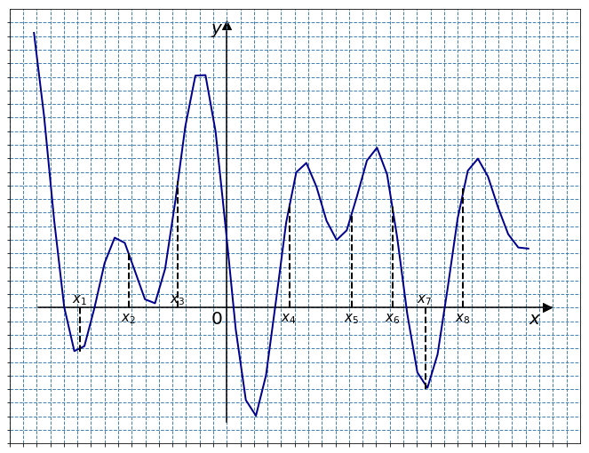

```python
f = plt.figure(figsize=(12,9))
ax = f.add_subplot(1, 1, 1, aspect=1)
ax.grid(c='steelblue', ls='--', lw=1)
ax.axhline(0, 0.05, 0.95, c='black')
ax.axvline(0, 0.05, 0.95, c='black')

def f(x,a=7,b=0.4,c=1.5,d=3.1,e=2.5):
    exp = (math.pow(x, 2) + math.pow(x, 5)) * (-0.1)**5
    return a * math.exp(exp) * math.cos(b*x+d) * math.sin(c*x)+e

x = numpy.linspace(-7.1,11.1)
y = [f(el) for el in x]
ax.plot(x, y, c='darkblue', lw=2)

vl = [-5.4,-3.6,-1.8,2.3,4.6,6.1,7.3,8.7]
for v in vl:
    ax.plot([v,v], [0,f(v)], lw=2, ls='--', c='black')

v = numpy.array([vl, [0.2,-0.5,0.2,-0.5,-0.5,-0.5,0.2,-0.5,0.2],
                 [r'$x_1$',r'$x_2$',r'$x_3$',r'$x_4$',r'$x_5$',
                  r'$x_6$',r'$x_7$',r'$x_8$']])
for i in range(8):
    plt.text(float(v[0][i])-0.3,float(v[1][i]),v[2][i],fontsize=15)

plt.text(11.1,-0.6,r'$x$', fontsize=20)
plt.text(-0.6,10.1,r'$y$', fontsize=20)
ax.scatter(11.8,0, marker='>', s=100, c='black')
ax.scatter(0,10.4, marker='^', s=100, c='black')
plt.text(-0.6,-0.6,r'$0$', fontsize=20)

plt.xlim(-8,13)
plt.ylim(-5,11)
plt.xticks(numpy.arange(-8,13, step=0.5), visible=False)
plt.yticks(numpy.arange(-5,11, step=0.5), visible=False);
```

Промежуткам убывания принадлежат те точки, в которых производная отрицательна.

The dots belong to the intervals of decrease if the derivative is negative in these points.

$x_1,x_7$

### Ответ / Answer: 2

```python
answer_dictionary[7] = str(2)
```

[figure not shown]

### Задание 8 / Task 8

Около шара описан цилиндр, площадь поверхности которого равна 15.

Найдите площадь поверхности шара.

A cylinder with a surface area of 15 is circumscribed around a sphere.

Find the surface area of the sphere.

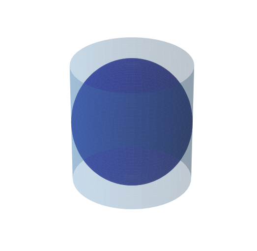

```python
f = plt.figure(figsize=(9,9))
ax = f.add_subplot(111, projection='3d')

def create_sphere(center_x,center_y,center_z,radius):
    u, v = numpy.mgrid[0:2*numpy.pi:50j, 0:numpy.pi:50j]
    x_grid = center_x + radius*numpy.cos(u)*numpy.sin(v)
    y_grid = center_x + radius*numpy.sin(u)*numpy.sin(v)
    z_grid = center_x + radius*numpy.cos(v)
    return x_grid,y_grid,z_grid

Xc,Yc,Zc = create_sphere(2.5,2.5,2.5,2.5)
ax.plot_surface(Xc, Yc, Zc, alpha=0.5, color='darkblue')

def create_cylinder(center_x,center_y,radius,height):
    z = numpy.linspace(0, height, 50)
    theta = numpy.linspace(0, 2*numpy.pi, 50)
    theta_grid, z_grid = numpy.meshgrid(theta, z)
    x_grid = radius * numpy.cos(theta_grid) + center_x
    y_grid = radius * numpy.sin(theta_grid) + center_y
    return x_grid,y_grid,z_grid

Xc,Yc,Zc = create_cylinder(2.5,2.5,2.5,5)
ax.plot_surface(Xc, Yc, Zc, alpha=0.3, color='steelblue')

plt.axis('off');
```

Радиусы шара и основания цилиндра равны $R$. Высота цилиндра равна $2 * R$.

The radii of the ball and the base of the cylinder are equal to $R$. The height of the cylinder is $2 * R$.

Площадь полной поверхности цилиндра равна сумме удвоенной площади основания и площади боковой поверхности:

The total surface area of the cylinder is equal to the sum of the doubled area of the base and the area of the lateral surface:

$S_{cylinder} = 2 * \pi * R^2 + 2 * \pi * R * 2 * R = 6 * \pi * R^2$

$S_{ball} = 4 * \pi * R^2 \implies S_{ball} \ / \ S_{cylinder} = 4 * \pi * R^2 \ / \ 6 * \pi * R^2 = 2 / 3$

$S_{ball} = 2 * S_{cylinder} \ / \ 3 = 2 * 15 / 3 = 10$

### Ответ / Answer: 10

```python
answer_dictionary[8] = str(10)
```

[figure not shown]

### Задание 9 / Task 9

Найдите значение выражения

Find the value of the expression

$\large{\frac{(\sqrt{8} + \sqrt{6})^2}{7 + \sqrt{48}}}$

$\large{\frac{(\sqrt{8} + \sqrt{6})^2}{7 + \sqrt{48}} = \frac{8 + 2 * \sqrt{48} + 6}{7 + \sqrt{48}} = \frac{2 * (7 + \sqrt{48})}{7 + \sqrt{48}}} = $ $2$

### Ответ / Answer: 2

```python
answer_dictionary[9] = str(2)
```

[figure not shown]

### Задание 10 / Task 10

При адиабатическом процессе для идеального газа выполняется закон

$p * V^k = const$, где $p$ - давление газа в паскалях, $V$ - объем газа в кубических метрах.

В ходе эксперимента с одноатомным идеальным газом (для него $k = \large{\frac{5}{3}}$) из начального состояния, в котором

$const = 2.916 * 10^5 Па*м^2$, газ начинают сжимать.

Какой наибольший объем $V$ может занимать газ при давлениях $p$ не ниже $3.75 * 10^6 Па$?

Ответ выразите в кубических метрах.

In the adiabatic process, the ideal gas is satisfied by the law

$p * V^k = const$, where $p$ is the gas pressure in pascals, $V$ is the gas volume in cubic meters.

In the course of the experiment with the monatomic ideal gas (for it, $k = \large {\frac {5}{3}}$) from the initial state in which

$const = 2.916 * 10^5 Pa * m^2$, the gas begins to compress.

Which largest volume $V$ can the gas occupy at pressures $p$ not lower than $3.75 * 10^6 Pa$?

The answer should be expressed in cubic meters.

Подставим имеющиеся данные в уравнение адиабатического процесса.

Let's substitute the available data in the equation of the adiabatic process.

$3.75 * 10^6 * V^{\large{\frac{5}{3}}} = 2.916 * 10^5$

${\large {V^{\frac{5}{3}}} = \frac{0.2916}{3.75}}$

${\large {V^{\frac{1}{3}}} = 0.0776^{\frac{1}{5}}}$

${\large {V^{\frac{1}{3}}} = 0.6}$

$V = 0.216$

### Ответ / Answer: 0.216

```python
answer_dictionary[10] = str((2.916/10/3.75)**0.6)
```

[figure not shown]

### Задание 11 / Task 11

Смешав 84-процентный и 96-процентный растворы кислоты и добавив 10 кг чистой воды, получили 84-процентный раствор кислоты.

Если бы вместо 10 кг воды добавили 10 кг 50-процентного раствора той же кислоты, то получили бы 89-процентный раствор кислоты.

Сколько килограммов 84-процентного раствора использовали для получения смеси?

Mixing 84 percent and 96 percent acid solutes and adding 10 kg of pure water, the 84 percent acid solute was obtained.

If 10 kg of a 50 percent solute of the same acid were added instead of 10 kg of water, an 89 percent acid solute would be obtained.

How many kilograms of an 84 percent solute was used to make the mixture?

Пусть x - масса 84-процентного раствора, y - 96-процентного.

Let x be the mass of the 84 percent solute, y - 96 percent.

$\begin {cases} 0.84 * x + 0.96 * y = 0.84 * (x + y + 10) \\ 0.84 * x + 0.96 * y + 0.5 * 10 = 0.89 * (x + y + 10) \end{cases} \iff \begin {cases} 0.96 * y = 0.84 * y + 8.4 \\ 0.07 * y = 0.05 * x + 3.9 \end{cases} \iff \begin {cases} y = 70 \\ x = 1.4 * y - 78 \end{cases} \iff \\ \iff x = 1.4 * 70 - 78 = 20$

### Ответ / Answer: 20

```python
answer_dictionary[11] = str(20)
```

[figure not shown]

### Задание 12 / Task 12

Найдите наименьшее значение функции

Find the least value of the function

$y = x^2 - 3 * x + ln \ x + 10$

на отрезке $\bigg[\large{\frac{3}{4};\frac{5}{4}}\bigg]$.

on the interval $\bigg[\large{\frac{3}{4};\frac{5}{4}}\bigg]$.

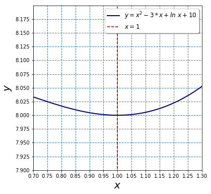

```python
f = plt.figure(figsize=(6,6))
ax = f.add_subplot(1, 1, 1)
ax.grid(c='steelblue', ls='--', lw=1)

def f(x):
    return x ** 2 - 3 * x + math.log(x,math.e) + 10

x = numpy.linspace(0.7,1.3)
y = [f(el) for el in x]
ax.plot(x, y, c='darkblue', lw=2,
        label=r'$y = x^2 - 3 * x + ln \ x + 10$')

ax.axvline(1, 0.01, 0.99, c='darkred',
           ls='--',label=r'$x=1$')

plt.xlim(0.7,1.3)
plt.ylim(7.9,8.2)
plt.xticks(numpy.arange(0.7,1.3, step=0.05))
plt.yticks(numpy.arange(7.9,8.2, step=0.025))

plt.xlabel(r'$x$', fontsize=20)
plt.ylabel(r'$y$', fontsize=20)
plt.legend(fontsize=12, shadow=True, loc=1);
```

Наименьших значений непрерывная функция может достигать в точках, где первая производная равна нулю, а вторая производная положительна.

The minimum value of a continuous function can be reached at points where the first derivative is equal to zero, and the second derivative is positive.

```python
x = Symbol('x')
y = x ** 2 - 3 * x + log(x,E) + 10
```

```python
# производная | the first derivative
diff(y,x)
```

$$2 x - 3 + \frac{1}{x}$$

```python
# производная равна нулю ∣ the first derivative is 0
solve(diff(y,x),x)
```

$$\left [ \frac{1}{2}, \quad 1\right ]$$

```python
# вторая производная / the second derivative
diff(diff(y,x),x)
```

$$2 - \frac{1}{x^{2}}$$

```python
# y''(0.5) < 0 => max
diff(diff(y,x),x).subs({x:0.5})
```

$$-2.0$$

```python
# y''(1) > 0 => min
diff(diff(y,x),x).subs({x:1})
```

$$1$$

```python
# y(1)
y.subs({x:1})
```

$$8$$

### Ответ / Answer: 8

```python
answer_dictionary[12] = str(y.subs({x:1}))
```

## Часть 2 Part 2

[figure not shown]

### Задание 13 / Task 13

a) Найдите корень уравнения:

a) Find the root of the equation:

$12 * \cos^2 x - 11 * \cos \ x + 2 = 0$.

б) Найдите все корни этого уравнения, принадлежащие промежутку

b) Find all the roots of this equation that belong to the interval

[-2π; -π].

a)

$12 * \cos^2 x - 11 * \cos \ x + 2 = 0$

$D = 121 - 4 * 2 * 12 = 25$

$cos \ x = \large{\frac{11 \pm \sqrt{25}}{2 * 12}}$

$cos \ x = \large{\frac{1}{4}}$$ \; \lor \; cos \ x = \large{\frac{2}{3}}$

$x = \pm arccos\frac{1}{4} \pm 2 * \pi * n$$ \; \lor \; x = \pm \arccos \frac{2}{3} \pm 2 * \pi * k; \; n,k \in \mathbb{N}$

б)

$-2 * \pi + arccos\frac{1}{4}; \; -2 * \pi + arccos\frac{2}{3}$

### Ответ / Answer:

#### a) $\pm arccos \frac{1}{4} \pm 2 * \pi * n$$ \; \lor \; \pm arccos \frac{2}{3} \pm 2 * \pi * k; \; n,k \in \mathbb{N}$;

#### б) $-2 * \pi + arccos\frac{1}{4}; \; -2 * \pi + arccos\frac{2}{3}$

```python
# check the decision method
x = Symbol('x')
g = 12 * (cos(x)) ** 2  - 11 * cos(x) + 2
```

```python
g
```

$$12 \cos^{2}{\left (x \right )} - 11 \cos{\left (x \right )} + 2$$

```python
solve(g,x)
```

$$\left [ - \operatorname{acos}{\left (\frac{1}{4} \right )} + 2 \pi, \quad - \operatorname{acos}{\left (\frac{2}{3} \right )} + 2 \pi, \quad \operatorname{acos}{\left (\frac{1}{4} \right )}, \quad \operatorname{acos}{\left (\frac{2}{3} \right )}\right ]$$

```python
N(-2 * pi), N(solve(g,x)[3] - 2 * pi), N(solve(g,x)[2] - 2 * pi), N(-pi)
```

$$\left ( -6.28318530717959, \quad -5.44211663661166, \quad -4.96506923552677, \quad -3.14159265358979\right )$$

```python
answer_dictionary[13] = 'a)±arccos(1/4)±2πn ∨ ±arccos(2/3)±2πk; n,k∈ℕ; б)−2π+arccos(1/4);−2π+arccos(2/3)'
```

[figure not shown]

### Задание 14 / Task 14

В правильной треугольной пирамиде SABC с вершиной S, все ребра которой равны 4:

- точка N - середина ребра AC,
- точка O - центр основания пирамиды,
- точка P делит отрезок SO в отношении 3 : 1, считая от вершины пирамиды.

а) Докажите, что прямая NP перпендикулярна прямой BS.

б) Найдите расстояние от точки B до прямой NP.

In the right triangular pyramid SABC with vertex S, all edges of which are equal to 4:

- the point N - the middle of the edge AC,
- the point O - the center of the base of the pyramid,
- the point P divides the segment SO in a ratio of 3 : 1, counting from the top of the pyramid.

a) Prove that the line NP is perpendicular to the line BS.

b) Find the distance from the point B to the line NP.

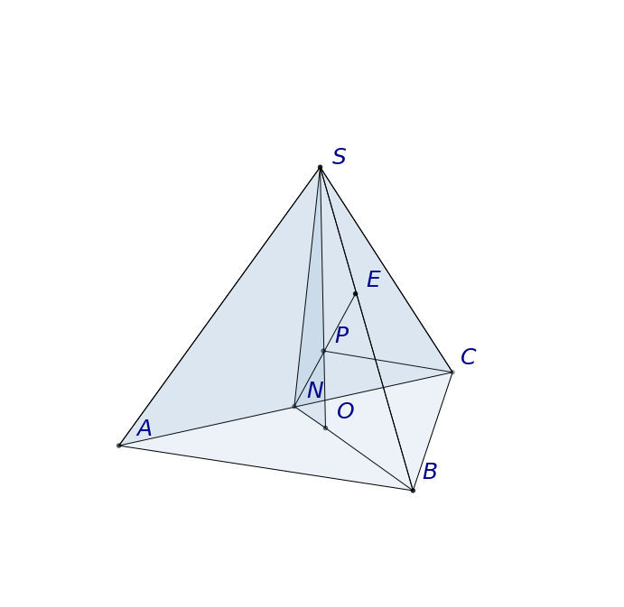

```python
f = plt.figure(figsize=(12,12))
ax = f.add_subplot(111, projection='3d')

v = numpy.array([[-1,-1,-1],[0.5,1,-1],[1,-0.5,-1],[0,0,1],
                 [0.1,-0.1,-1],[-0.23,0.04,-1],[0.06,-0.06,-0.4],[0.62,-0.62,0.5]])
letters = [r'$A$', r'$C$',r'$B$',r'$S$',r'$O$',r'$N$',r'$P$',r'$E$']

ax.scatter3D(v[:, 0],v[:, 1],v[:, 2],color='black')

verts = [ [v[0],v[1],v[3]], [v[0],v[2],v[3]],
          [v[2],v[1],v[3]], [v[3],v[4],v[5]],
          [v[7],v[5]],[v[2],v[4]],[v[1],v[6]] ]

piramid = Poly3DCollection(verts,lw=1,alpha=0.1,
                           edgecolors='black',facecolor='none')
piramid.set_facecolor('steelblue')
ax.add_collection3d(piramid)
for i in range(8):
    ax.text(v[i][0]-0.2,v[i][1]+0.5,v[i][2]-0.25,
            letters[i],fontsize=25,color='darkblue')

plt.axis('off');
```

а)

$SO \cap BN = O, P \in SO \implies NP \subset (NSB) \implies NP \cap SB = E$

$AB = BC = AC = SA = SB = SC = 4, AN = NC = 2 \implies NB = \sqrt{4^2 - 2^2} = 2\sqrt{3}$

O - точка пересечения медиан правильного $\triangle ABC$

O is the point of intersection of the medians of the equilateral $\triangle ABC$

$\implies BO/NO = 2/1 \implies BO = 4\sqrt{3}/3, NO = 2\sqrt{3}/3$

$\triangle SOB: SO = \sqrt{SB^2 - SO^2} = \sqrt{4^2 - (4\sqrt{3}/3)^2} = 4\sqrt{6}/3$

$SP:PO = 3:1 \implies PO = SO/4 = \sqrt{6}/3$

$\triangle ENB: ctg\angle ENB = NO/PO = 2\sqrt{3}/3 : \sqrt{6}/3 = \sqrt{2}; \; ctg\angle EBN = BO/SO = 4\sqrt{3}/3 : 4\sqrt{6}/3 = \sqrt{2}/2$

$ctg(\angle ENB + \angle EBN) = (ctg\angle ENB * ctg\angle EBN - 1)/(ctg\angle ENB + ctg\angle EBN) = (\sqrt{2} * \sqrt{2}/2 - 1) / (\sqrt{2} + \sqrt{2}/2) = 0$

$\angle EBN + \angle ENB = 90^o \implies \angle NEB = 90^o \implies NE \bot SB \equiv NP \bot SB$

б)

$SN, BN$ - биссектрисы, медианы и высоты в правильных и равных $\triangle SAC, \triangle ABC$.

$SN, BN$ - bisectors, medians and heights in equilateral and equal $\triangle SAC, \triangle ABC$.

$\triangle SNB: SN = BN, NE \bot SB \implies BE = SE = SB / 2 = 4 / 2 = 2$

### Ответ / Answer: б) 2

```python
answer_dictionary[14] = 'б) 2'
```

[figure not shown]

### Задание 15 / Task 15

Решите неравенство:

Solve the inequality:

$\large{\frac{2 * x^2 - 8 * x}{x - 7}}$$\leq x$

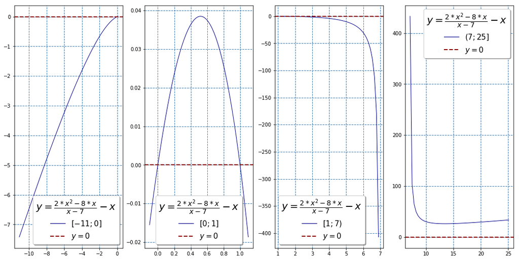

```python
f,[ax1,ax2,ax3,ax4] = plt.subplots(nrows=1,ncols=4,figsize=(18, 9))

def f(el):return (2 * el ** 2 - 8 * el)/(el - 7) - el

x1 = numpy.linspace(-11.1,0.1)
y1 = [f(el) for el in x1]
x2 = numpy.linspace(-0.1,1.1)
y2 = [f(el) for el in x2]
x3 = numpy.linspace(1.1,6.9)
y3 = [f(el) for el in x3]
x4 = numpy.linspace(7.1,25.1)
y4 = [f(el) for el in x4]

ax1.plot(x1, y1, c='darkblue', lw=1,
        label=r'$[-11;0]$')
ax2.plot(x2, y2, c='darkblue', lw=1,
        label=r'$[0;1]$')
ax3.plot(x3, y3, c='darkblue', lw=1,
        label=r'$[1;7)}$')
ax4.plot(x4, y4, c='darkblue', lw=1,
        label=r'$(7;25]}$')

for p in [ax1,ax2,ax3,ax4]:
    p.grid(c='steelblue', ls='--', lw=1)

    p.axhline(0, c='darkred',ls='--',lw=2,label=r'$y = 0$')

    p.legend(title=r'$y = \frac{2 * x^2 - 8 * x}{x - 7} - x$',
          fontsize=15, shadow=True)
    p.get_legend().get_title().set_fontsize(20)
```

1) Область допустимых значений / Range of admissible values

$x - 7 \neq 0 \iff x \neq 7$

2) Преобразования неравенства / Inequality transformations

$\large{\frac{2 * x^2 - 8 * x}{x - 7}}$$\leq x$

$\begin{cases} x - 7 > 0 \\ 2 * x^2 - 8 * x \leq x * (x - 7) \end{cases} \lor \begin{cases} x - 7 < 0 \\ 2 * x^2 - 8 * x \geq x * (x - 7) \end{cases} \iff \begin{cases} x > 7 \\ x^2 - x \leq 0 \end{cases} \lor \begin{cases} x < 7 \\ x^2 - x \geq 0 \end{cases} \iff$

$\iff \begin{cases} x > 7 \\ x * (x - 1) \leq 0 \end{cases} \lor \begin{cases} x < 7 \\ x * (x - 1) \geq 0 \end{cases} \iff \begin{cases} x > 7 \\ 0 \leq x \leq 1 \end{cases} \lor \begin{cases} x < 7 \\ x \leq 0 \lor x \geq 1 \end{cases} \iff x \in \emptyset \; \lor \; x \leq 0 \; \lor \; 1 \leq x < 7$

### Ответ / Answer: $(-\infty;0] \cup [1;7)$

```python
answer_dictionary[15] = '(−∞;0]∪[1;7)'
```

[figure not shown]

### Задание 16 / Task 16

Дана трапеция $ABCD$ с боковыми сторонами $AB = 27$, $CD = 28$ и основанием $BC = 5$.

Известно, что $\cos \angle BCD = - \large{\frac{2}{7}}$.

а) Докажите, что расстояние от основания высоты, опущенной из вершины B на прямую $AD$, до вершины $A$ равно 3.

б) Найдите диагональ $AC$.

A trapezoid $ABCD$ with sides $AB = 27$, $CD = 28$ and the base $BC = 5$ is given.

It is known that $\cos \angle BCD = - \large {\frac{2}{7}}$.

a) Prove that the distance from the base of the height dropped from the vertex B to the line $AD$ to the vertex $A$ is 3.

b) Find the diagonal $AC$.

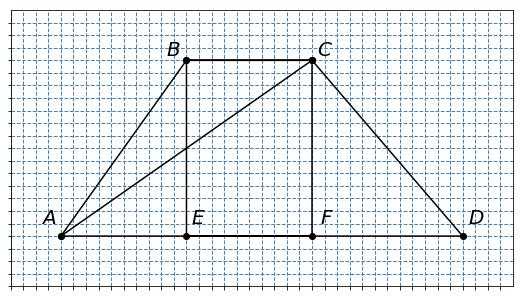

```python
f = plt.figure(figsize=(9,9))
ax = f.add_subplot(1, 1, 1, aspect=1)
ax.grid(c='steelblue', ls='--', lw=1)

ax.plot([-8,8,2,-3,-8,2,-3,-3,2,2],
        [-8,-8,-1,-1,-8,-1,-1,-8,-8,-1],
        '-o', c='black')

v = numpy.array([[-8.8,8.2,-3.8,2.2,-2.8,2.3],
                 [-7.5,-7.5,-0.8,-0.8,-7.5,-7.5],
                 [r'$A$',r'$D$',r'$B$',r'$C$',r'$E$',r'$F$']])

for i in range(6):
    plt.text(float(v[0][i]),float(v[1][i]),v[2][i],fontsize=20)

plt.xlim(-10,10)
plt.ylim(-10,1)
plt.xticks(numpy.arange(-10, 10, step=0.5), visible=False)
plt.yticks(numpy.arange(-10, 1, step=0.5), visible=False);
```

а)

Построим высоты $BE$, $CF$ трапеции $ABCD$ из вершин $B$ и $C$.

Let's construct the heights $BE$, $CF$ of the trapezoid $ABCD$ from the vertices $B$ and $C$.

$BE \bot BC, BE \bot AD, CF \bot BC, CF \bot AD, EF = BC = 5, BE = CF$

$\angle BCD = 90^o + \angle FCD \implies \cos(\angle BCD) = \cos(90^o + \angle FCD) = - \sin(\angle FCD) \implies \sin(\angle FCD) = \large {\frac{2}{7}}$

$\cos(\angle FCD) = \sqrt{1 - \sin^2(\angle FCD)}= \large {\frac{3\sqrt{5}}{7}}$

$\cos(\angle FCD) = CF / CD \implies CF = CD * \cos(\angle FCD)= 28 * \large {\frac{3\sqrt{5}}{7}}$$= 12\sqrt{5}$

$\triangle ABE: AE = \sqrt{AB^2 - BE^2} = \sqrt{27^2 - (12\sqrt{5})^2} = 3 * \sqrt{9^2 - 4^2 * 5} = 3 * \sqrt{81 - 80} = 3$

б)

$AF = EF + AE = 5 + 3 = 8$

$\triangle ACF: AC = \sqrt{AF^2 + CF^2} = \sqrt{8^2 + (12\sqrt{5})^2} = 4 * \sqrt{2^2 + 3^2 * 5} = 4 * \sqrt{4 + 45} = 28$

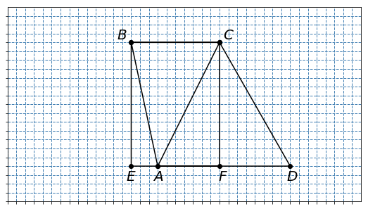

```python
f = plt.figure(figsize=(9,9))
ax = f.add_subplot(1, 1, 1, aspect=1)
ax.grid(c='steelblue', ls='--', lw=1)

ax.plot([-1.5,6,2,-3,-1.5,2,-3,-3,2,2],
        [-8,-8,-1,-1,-8,-1,-1,-8,-8,-1],
        '-o', c='black')

v = numpy.array([[-1.8,5.8,-3.8,2.2,-3.3,1.9],
                 [-8.8,-8.8,-0.8,-0.8,-8.8,-8.8],
                 [r'$A$',r'$D$',r'$B$',r'$C$',r'$E$',r'$F$']])

for i in range(6):
    plt.text(float(v[0][i]),float(v[1][i]),v[2][i],fontsize=20)

plt.xlim(-10,10)
plt.ylim(-10,1)
plt.xticks(numpy.arange(-10, 10, step=0.5), visible=False)
plt.yticks(numpy.arange(-10, 1, step=0.5), visible=False);
```

а)

Рассуждения аналогичны./ The reasoning is similar.

б)

$AF = EF - AE = 5 - 3 = 2$

$\triangle ACF: AC = \sqrt{AF^2 + CF^2} = \sqrt{2^2 + (12\sqrt{5})^2} = 2 * \sqrt{1 + 6^2 * 5} = 2 * \sqrt{1 + 180} = 2\sqrt{181}$

### Ответ / Answer: б) $28 \lor 2\sqrt{181}$

```python
answer_dictionary[16] = 'б) 28 ∨ 2√181'
```

[figure not shown]

### Задание 17 / Task 17

15-го января планируется взять кредит в банке на 20 месяцев.

Условия возврата таковы:

- 1-го числа каждого месяца долг возрастает на 2% по сравнению с концом предыдущего месяца;
- со 2-го по 14-ое число каждого месяца необходимо выплатить часть долга;
- 15-го числа каждого месяца долг должен быть на одну и ту же величину меньше долга на 15-е число предыдущего месяца.

Сколько процентов от суммы кредита составляет общая сумма денег, которую нужно ылатить банку за весь срок кредитования?

On January 15, it is planned to take a loan in the bank for 20 months.

Terms of return are as follows:

- on the first day of each month, the debt grows by 2% compared to the end of the previous month;
- from the 2nd to the 14th day of each month, it is necessary to pay a part of the debt;
- on the 15th day of each month, the debt should be on the same amount less than the debt on the 15th day of the previous month.

How much is the total amount of money (in a percentage of the loan) that you need to pay the bank for the entire loan period?

Кредит возвращается 20 равными платежами по $1/20$ от суммы кредита $S$ и начисленных за весь период процентов:

- в первом месяце процентов начисляется $0.02∗S$,
- после уплаты части долга во втором месяце начисляется на $1/20$ меньше процентов $0.02 ∗ 19/20 ∗ S$,
- в третьем месяце $0.02 ∗ 18/20 ∗ S$,
- ...,
- последнее начисление процентов $0.02 ∗ 1/20 ∗ S$.

Сумма всех начисленных процентов будет равна

$0.02 ∗ S ∗(1 + 19/20 + ... + 1/20) = 0.02 ∗ S ∗ (1 + 1/20) / 2 ∗ 20 = 0.02 ∗ S ∗ 21/20 * 20 / 2 = 0.21 ∗ S$.

$0.21 ∗ S$ составляет 21 процент от размера кредита $S$.

The loan is returned by 20 equal installments - $1/20$ of the loan amount $S$ and the interest accrued for the entire period:

- in the first month, the interest is charged $0.02∗S$,
- after paying a part of the debt in the second month, it becomes $0.02 ∗ 19/20 ∗ S$,
- in the third month, $0.02 ∗ 18/20 ∗ S$,
- ...,
- the last accrual of interest $0.02 ∗ 1/20 ∗ S$.

The amount of all accrued interest will be

$0.02 ∗ S ∗(1 + 19/20 + ... + 1/20) = 0.02 ∗ S ∗ (1 + 1/20) / 2 ∗ 20 = 0.02 ∗ S ∗ 21/20 * 20 / 2 = 0.21 ∗ S$.

$0.21 ∗ S$ is 21 percent of the loan size $S$.

### Ответ / Answer: 21.

```python
answer_dictionary[17] = str(21)
```

[figure not shown]

### Задание 18 / Task 18

Найдите все значения параметра a, при каждом из которых неравенство

Find all the values of the parameter a, for each of which the inequality

$x^2 - a * (a^2 + 1) * x + a^4 < 0$

имеет решение и множество решений неравенства содержится на интервале (-3;1).

has a solution and the solution set of the inequality is contained on the interval (-3; 1).

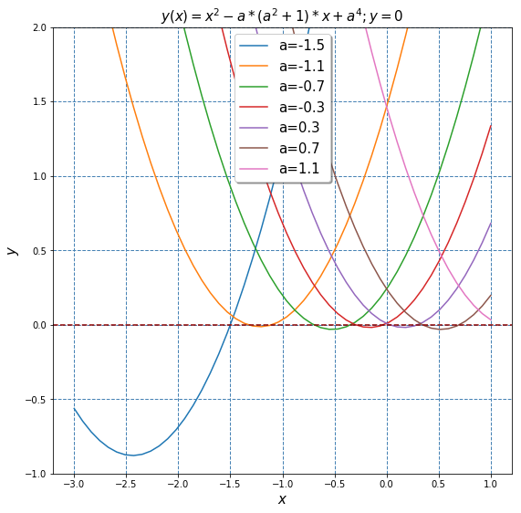

```python
def F(x,a): return x ** 2 - a * (a ** 2 + 1) * x + a ** 4
X = numpy.linspace(-3, 1)

plt.figure(figsize=(9,9))
for a in [-1.5, -1.1, -0.7, -0.3, 0.3, 0.7, 1.1]:
    plt.plot(X, [F(x,a) for x in X], label='a='+str(a))

plt.axhline(0, c='darkred', ls='--')
plt.legend(shadow=True, loc=9, fontsize=15)
plt.xlabel(r'$x$', fontsize=15)
plt.ylabel(r'$y$', fontsize=15)
plt.ylim(-1,2)

plt.title(r'$y(x) = x^2 - a * (a^2 + 1) * x + a^4; y = 0$', fontsize=15)
plt.grid(c='steelblue', ls='--', lw=1);
```

а)

Неравенство выполняется, только если $x^2 - a * (a^2 + 1) * x + a^4 = 0$ имеет два корня.

The inequality is satisfied only if $x^2 - a * (a^2 + 1) * x + a^4 = 0$ has two roots.

$D > 0$

$(a * (a^2 + 1))^2 - 4 * 1 * a^4 > 0$

$a^2 * (a^4 + 2 * a^2 + 1) - 4 * a^4 > 0$

$a^2 * (a^4 - 2 * a^2 + 1) > 0$

$a^2 * (a^2 - 1)^2 > 0$

$a \neq -1; a \neq 0; a \neq 0$

б)

Множество решений неравенства содержится на интервале (-3;1), если:

The set of solutions of the inequality is contained on the interval (-3; 1) if:

$\begin {cases} ( \; a * (a^2 + 1) - \sqrt{a^2 * (a^2 - 1)^2} \; ) / 2 \geq -3 \\ (\; a * (a^2 + 1) + \sqrt{a^2 * (a^2 - 1)^2} \; ) / 2 \leq 1 \end {cases}$

$\begin {cases} a * (a^2 + 1) - |a * (a^2 - 1)| \geq -6 \\ a * (a^2 + 1) + |a * (a^2 - 1)| \leq 2 \end {cases}$

I.

$\begin {cases} a * (a^2 - 1) > 0 \\ a * (a^2 + 1) - |a * (a^2 - 1)| \geq -6 \\ a * (a^2 + 1) + |a * (a^2 - 1)| \leq 2 \end {cases}$

$\begin {cases} a * (a - 1) * (a + 1) > 0 \\ 2 * a \geq -6 \\ 2 * a^3 \leq 2 \end {cases} \iff \begin {cases} -1 < a < 0 \lor a > 1 \\ a \geq -3 \\ a \leq 1 \end {cases} \iff -1 < a < 0$

II.

$\begin {cases} a * (a^2 - 1) < 0 \\ a * (a^2 + 1) + a * (a^2 - 1) \geq -6 \\ a * (a^2 + 1) - a * (a^2 - 1) \leq 2 \end {cases}$

$\begin {cases} a * (a - 1) * (a + 1) < 0 \\ 2 * a^3 \geq -6 \\ 2 * a \leq 2 \end {cases} \iff \begin {cases} 0 < a < 1 \lor a < -1 \\ a \geq -\sqrt[3]{3} \\ a \leq 1 \end {cases} \iff -\sqrt[3]{3} \leq a < -1 \lor 0 < a < 1$

### Ответ / Answer: $[-\sqrt[3]{3};-1) \cup (-1;0) \cup (0;1)$.

```python
answer_dictionary[18] = '[⎯3^(1/3);⎯1)∪(⎯1;0)∪(0;1)'
```

[figure not shown]

### Задание 19 / Task 19

Найдите корень уравнения в целых числах:

Find the root of the equation in integers:

$x^2 + x + 3 = y^2$

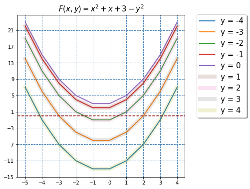

```python
def F(x,y): return x ** 2 + x + 3 - y ** 2
X = range(-5,5)

plt.figure(figsize=(6,6))
for y in range(-4,5):
    if y <= 0:
        lw,alpha = 2,1
    else:
        lw,alpha = 8,0.2
    plt.plot(X,[F(x,y) for x in X],alpha=alpha,lw=lw,label='y = '+str(y))

plt.xticks(numpy.arange(-5,5, step=1))
plt.yticks(numpy.arange(-15,25, step=4))
plt.axhline(0, c='darkred', ls='--')

plt.title(r'$F(x,y) = x^2 + x + 3 - y^2$', fontsize=15)
plt.legend(shadow=True, fontsize=15, bbox_to_anchor=(1.05, 1.025))
plt.grid(c='steelblue', ls='--', lw=1);
```

$x^2 + x + 3 = y^2$

$x^2 + x - 6 = y^2 - 9$

$(x + 3) * (x - 2) = (y - 3) * (y + 3)$

$(x + 3 = 0 \land y + 3 = 0) \lor (x + 3 = 0 \land y - 3 = 0) \lor (x - 2 = 0 \land y + 3 = 0) \lor (x - 2 = 0 \land y - 3 = 0)$

### Ответ / Answer: $(-3;-3),(-3;3),(2;-3),(2;3)$

```python
answer_dictionary[19] = '(⎯3;⎯3),(⎯3;3),(2;⎯3),(2;3)'
```

## Ответы / Answers

[output not shown]

| 13 | 14 | 15 | 16 | 17 | 18 | 19 |
| --- | --- | --- | --- | --- | --- | --- |
| a) $\pm arccos \frac{1}{4} \pm 2 * \pi * n$ $ \; \lor \; \pm arccos \frac{2}{3} \pm 2 * \pi * k;$ $\; n,k \in \mathbb{N}$; б) $-2 * \pi + arccos\frac{1}{4};$ $\; -2 * \pi + arccos\frac{2}{3}$ | б) 2 | $(-\infty;0] \cup [1;7)$ | б) $28 \lor 2\sqrt{181}$ | 21 | $[-\sqrt[3]{3};-1) \cup (-1;0) \cup (0;1)$ | $(-3;-3),(-3;3),(2;-3),(2;3)$ |

```python
answer_dictionary
```

```
{1: '4',
 2: '150000',
 3: '4',
 4: '0.25',
 5: '207',
 6: '92',
 7: '2',
 8: '10',
 9: '2',
 10: '0.216',
 11: '20',
 12: '8',
 13: 'a)±arccos(1/4)±2πn ∨ ±arccos(2/3)±2πk; n,k∈ℕ; б)−2π+arccos(1/4);−2π+arccos(2/3)',
 14: 'б) 2',
 15: '(−∞;0]∪[1;7)',
 16: 'б) 28 ∨ 2√181',
 17: '21',
 18: '[⎯3^(1/3);⎯1)∪(⎯1;0)∪(0;1)',
 19: '(⎯3;⎯3),(⎯3;3),(2;⎯3),(2;3)'}
```

[figure not shown]